# Project Python Foundations: FoodHub Data Analysis

#### Observations:

- Restaurant names, cuisine types, day of the week are categorical data
- Order id, customer id, cost, rating, prep time and delivery time are numerical data.
- Note : Some rating rows have value = “Not given”
- Min, max and mean values are shown above for numerical data
- SD, range and IQR are listed below:
  - Cost
    - Standard Déviation: 7.483812110049553
    - Range: 30.939999999999998
    - Interquartile Range: 10.2175
  - Preparation Time
    - Standard Déviation: 4.63248077592887
    - Range: 15
    - Interquartile Range: 8.0
  - Delivery time
    - Standard Déviation: 4.972636933991107
    - Range: 18
    - Interquartile Range: 8.0
- There are 1898 orders in total. There are 1200 unique customers, 178 unique restaurants and 14 unique cuisine types.
- Restaurant with biggest order count is Shake Shack with 219 orders. Company can look into why some restaurants have order rate as low as 1 if it’s due to cuisine, delivery time or something else.
- Cuisine with most orders is American with 584 orders. It means that American cuisine is most popular followed by Japanese and Italian. Further analysis can be done to see if there is even distribution of these orders across all restaurants serving that cuisine or some restaurants only.
- Customer with maximum orders is with Id 52832 with 13 orders.Customers having ordered a few times means some liking towards either cuisine, cost, timing or something else which can be determined by further analysis.
- Rating column has highest count of 736 of category “Not given”. This could be something company could look into to find if it’s due to complexity of the process of rating. Further analysis needs to be done to find if no rating has relationship to any specific restaurant or cuisine.

### **Question 7**: Which are the top 5 restaurants in terms of the number of orders received? [1 mark]

```python
# Write the code here

df['restaurant_name'].value_counts().head(5)
```

| restaurant_name | count |
| --- | --- |
| Shake Shack | 219 |
| The Meatball Shop | 132 |
| Blue Ribbon Sushi | 119 |
| Blue Ribbon Fried Chicken | 96 |
| Parm | 68 |

**dtype:** int64

#### Observations: The answer is as shown above in the output. The top restaurant alone has more than 10% of total orders. These 5 restaurants are popular. Company can incentivize on orders with theses restaurants.

### **Question 8**: Which is the most popular cuisine on weekends? [1 mark]

```python
# Write the code here

# first filter out the rows where day of the week value is weekend
weekend_orders = df[df['day_of_the_week'] == 'Weekend']
# group by cuisine type and sort by count
print(weekend_orders['cuisine_type'].value_counts())
```

```
cuisine_type
American          415
Japanese          335
Italian           207
Chinese           163
Mexican            53
Indian             49
Mediterranean      32
Middle Eastern     32
Thai               15
French             13
Korean             11
Southern           11
Spanish            11
Vietnamese          4
Name: count, dtype: int64
```

#### Observations: American cuisine is most popular cuisine over weekends based on given data set. Total number of American cuisine orders are 415 over the weekend which is a whopping over 20% of the total. Japanese and Italian are second and third respectively. Weekend orders are significantly more than Weekdays orders. Company can think of specials over the weekends to encourage more orders.

### **Question 9**: What percentage of the orders cost more than 20 dollars? [2 marks]

```python
# Write the code here

# First find rows with order cost more than 20 dollars
cost_over_20 = df[df['cost_of_the_order'] > 20].shape[0]

# Find percentage by dividing it by total rows(1898)
cost_over_20_percent = cost_over_20 / df.shape[0] * 100
print(cost_over_20_percent)
```

```
29.24130663856691
```

#### Observations: About 30% orders are over 20 dollars. One profit generation idea would be to add small cess for example 50 cents to the order to increase profits. I think customer paying over 20 dollars would not mind paying another 50 cents. Also specific and targeted marketing or add campaigns to such high paying customers on weekdays could increase chances of increased weekday orders. Also recommendation based on prior orders can be another strategy targeting these customers as its likely they would want to retry being high paying customers.

Note : The currency **dollars** is not mentioned under "Problem Statement - FoodHub". I am assuming it based on the question.

### **Question 10**: What is the mean order delivery time? [1 mark]

```python
# Write the code here

df['delivery_time'].mean()
```

```
24.161749209694417
```

#### Observations:

The 24 mins of delivery time can be benchmarked for improvements. Also this number can be used to compare with the competitors. Possibly after careful analysis also be used in advertisements if its already better than the competitors.

### **Question 11:** The company has decided to give 20% discount vouchers to the top 3 most frequent customers. Find the IDs of these customers and the number of orders they placed. [1 mark]

```python
# Write the code here
df['customer_id'].value_counts().head(3)
```

| customer_id | count |
| --- | --- |
| 52832 | 13 |
| 47440 | 10 |
| 83287 | 9 |

**dtype:** int64

#### Observations: Customer who ordered the most in given data set is with Id 52832. More analysis is need to find patterns in the ordering.

### **Question 12**: Perform a multivariate analysis to explore relationships between the important variables in the dataset. (It is a good idea to explore relations between numerical variables as well as relations between numerical and categorical variables) [10 marks]

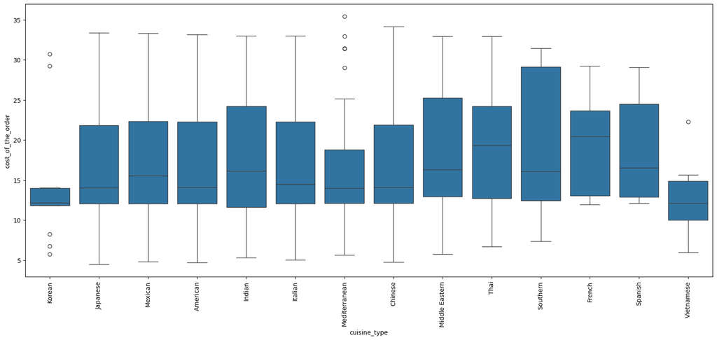

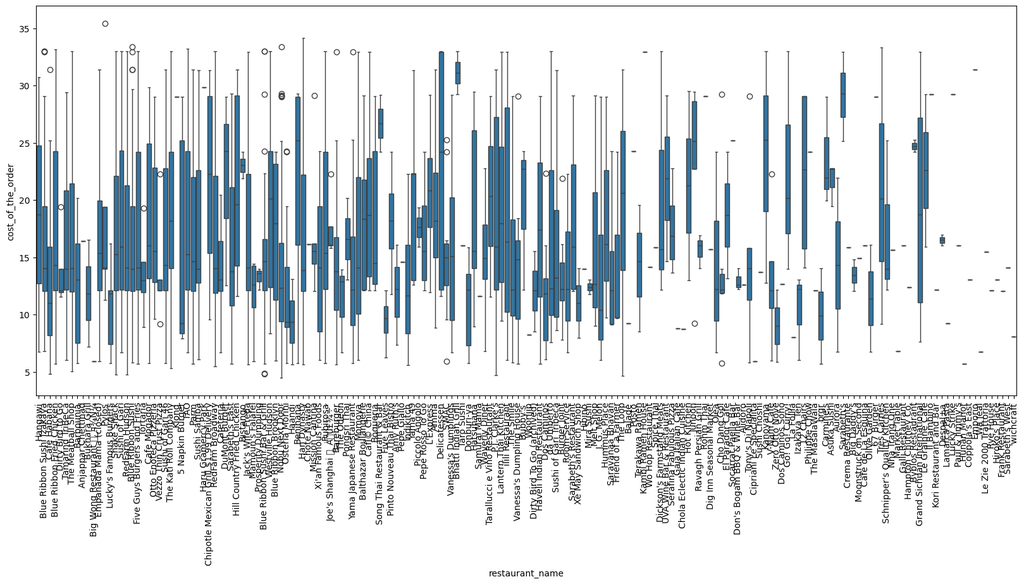

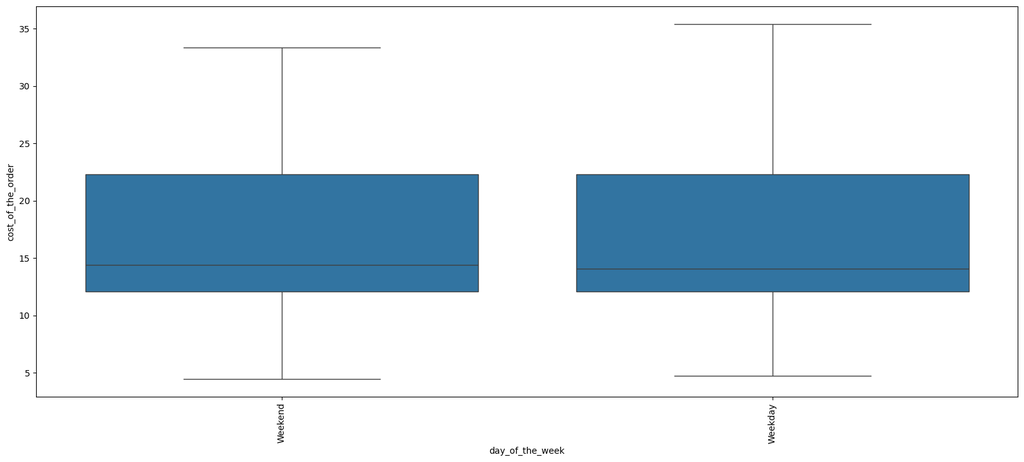

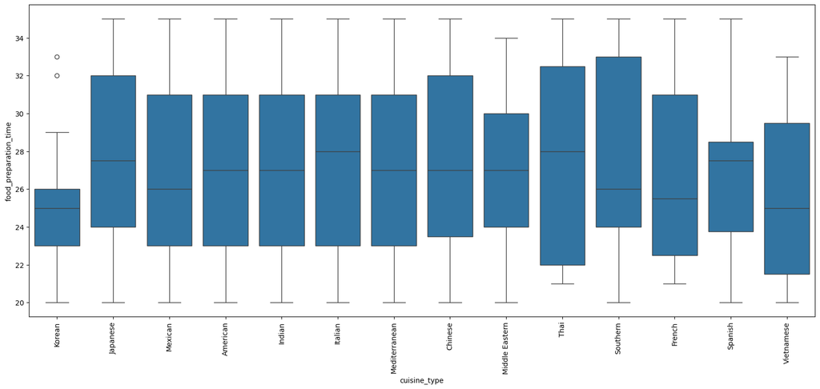

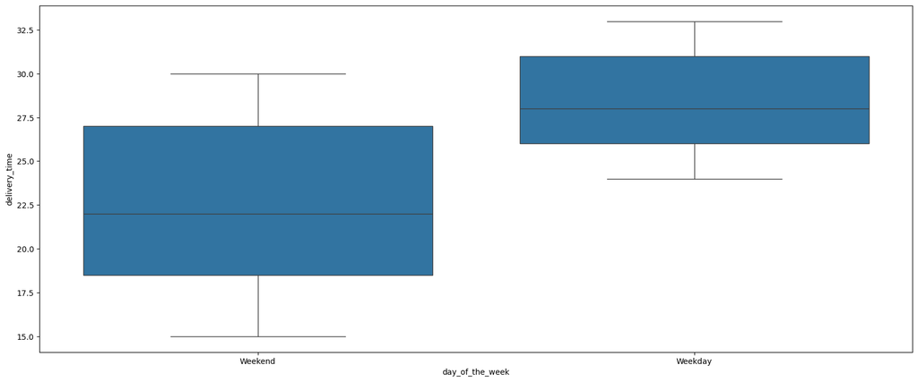

```
restaurant_name
Shake Shack                      3579.53
The Meatball Shop                2145.21
Blue Ribbon Sushi                1903.95
Blue Ribbon Fried Chicken        1662.29
Parm                             1112.76
RedFarm Broadway                  965.13
RedFarm Hudson                    921.21
TAO                               834.50
Han Dynasty                       755.29
Blue Ribbon Sushi Bar & Grill     666.62
Rubirosa                          660.45
Sushi of Gari 46                  640.87
Nobu Next Door                    623.67
Five Guys Burgers and Fries       506.47
Name: cost_of_the_order, dtype: float64
```

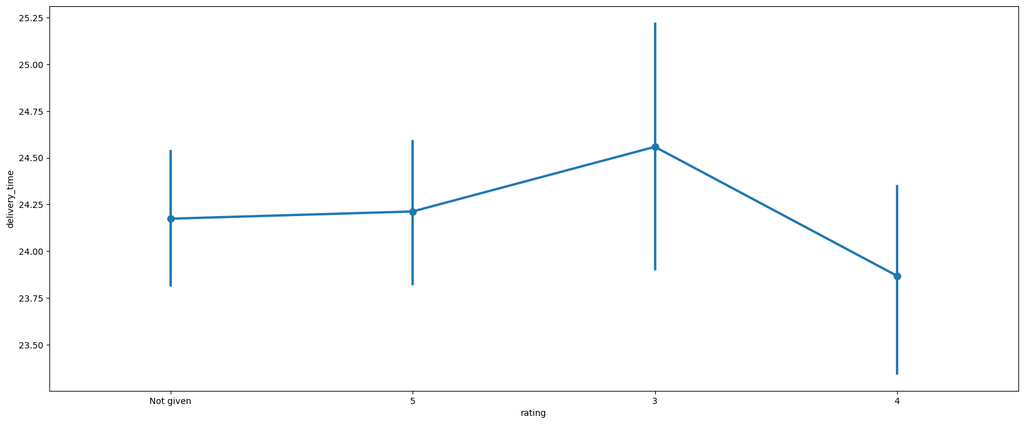

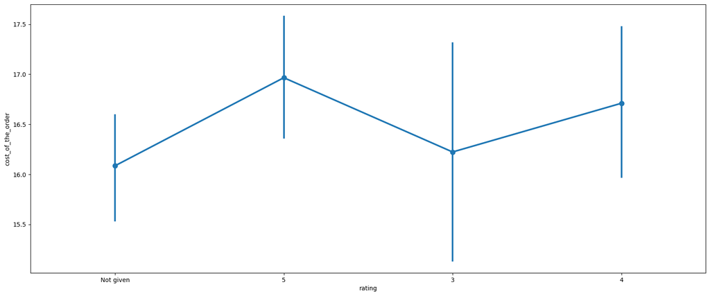

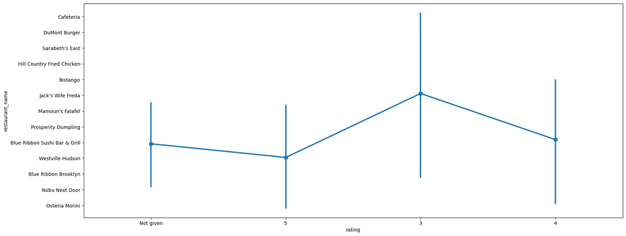

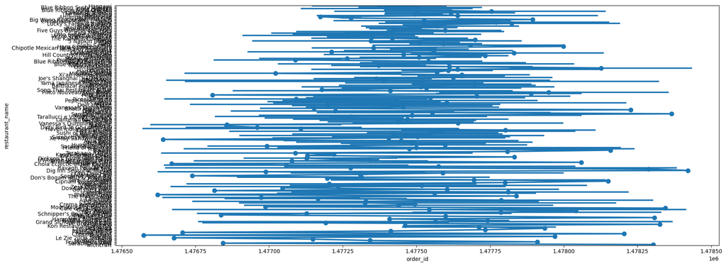

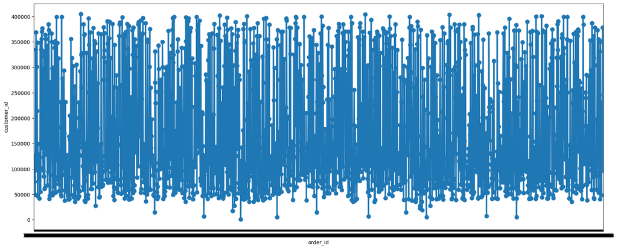

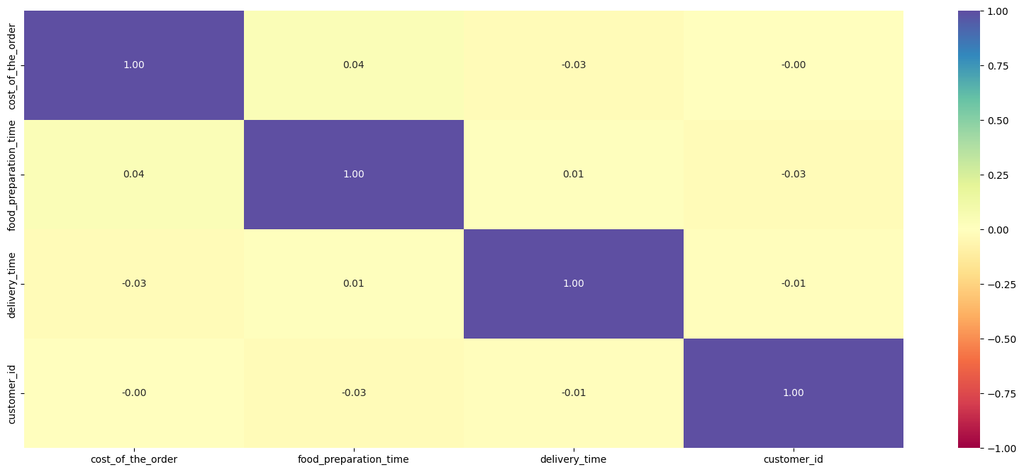

[figure not shown]

[1 more figures not shown]

[output not shown]

[output cut: 207 more lines]

[output not shown]

```python
# Write the code here

# Relationship between cost and cuisine type
plt.figure(figsize=(20,8))
sns.boxplot(x = "cuisine_type", y = "cost_of_the_order", data = df)
plt.xticks(rotation = 90)
plt.show()

# Relationship between order cost and restaurants
plt.figure(figsize=(20,8))
sns.boxplot(x = "restaurant_name", y = "cost_of_the_order", data = df)
plt.xticks(rotation = 90)
plt.show()

# Relationship between order cost and day of the week
plt.figure(figsize=(20,8))
sns.boxplot(x = "day_of_the_week", y = "cost_of_the_order", data = df)
plt.xticks(rotation = 90)
plt.show()

# Relationship between prep time and cuisine type
plt.figure(figsize=(20,8))
sns.boxplot(x = 'cuisine_type', y = 'food_preparation_time', data= df)
plt.xticks(rotation = 90)
plt.show()

# Relationship between Delivery Time and Day of the week
plt.figure(figsize=(20,8))
sns.boxplot (x = 'day_of_the_week', y = 'delivery_time', data = df)
plt.show()

# Business generated per Restaurant
print(df.groupby(['restaurant_name'])['cost_of_the_order'].sum().sort_values(ascending = False).head(14))

# Relationship between rating and Delivery Time
plt.figure(figsize=(20, 8))
sns.pointplot(x = 'rating', y = 'delivery_time', data = df)
plt.show()

# Relationship between rating and cost of the order
plt.figure(figsize=(20, 8))
sns.pointplot(x = 'rating' , y = 'cost_of_the_order' , data = df)
plt.show()

# Relationship between rating and restaurant
plt.figure(figsize=(20, 8))
sns.pointplot(x = 'rating' , y = 'restaurant_name' , data = df)
plt.show()

# Relationship between orders and restaurant
plt.figure(figsize=(20, 8))
sns.pointplot(x = 'order_id' , y = 'restaurant_name' , data = df)
plt.show()

# Relationship between orders and customer
plt.figure(figsize=(20, 8))
sns.pointplot(x = 'order_id' , y = 'customer_id' , data = df)
plt.show()

#Plot the heatmap
col_list = ['cost_of_the_order', 'food_preparation_time', 'delivery_time', 'customer_id']
plt.figure(figsize=(20, 8))
sns.heatmap(df[col_list].corr(), annot=True, vmin=-1, vmax=1, fmt=".2f", cmap="Spectral")
plt.show()

# Relationship between cost and prep time
plt.figure(figsize=(20,8))
sns.boxplot(y = "food_preparation_time", x = "cost_of_the_order", data = df)
plt.xticks(rotation = 90)
plt.show()

# Relationship between cost and delivery time
plt.figure(figsize=(20,8))
sns.boxplot(y = "delivery_time", x = "cost_of_the_order", data = df)
plt.xticks(rotation = 90)
plt.show()

print(df.groupby(['cuisine_type', 'day_of_the_week']).count())
print(df.groupby(['cuisine_type', 'rating']).count())
```

#### Observations:

- Korean , Mediterranean and Vietnamese cuisines have outliers for cost of the order. French cuisine has highest Median cost of the order value.
- Various restaurants have outliers for cost of the order.
- The min and median values of cost of the order against the day of the week are almost identical. Max value for weekday is more than weekend. There are no outliers on weekdays or weekends.
- Only Korean food has outliers as seen on the boxplot of food preparation time against cuisines. The min and max prep time is common across several cuisines.
- The delivery time varies significantly across weekday vs weekend as shown in the boxplot. The min value of delivery time on weekday is more than median value of delivery time on weekend.
- Shake Shack restaurant did maximum business with 3579.53 dollars
- The mean delivery time for orders with rating 5 is lesser than orders with ratings 3 but more than orders with rating 4
- The mean cost of the order is highest for orders with rating 5 followed by 4 followed by 3 followed by Not given
- There is no usable correlation between restaurant name, order id and customer id
- Order cost and food preparation time have positive correlation
- Order cost with delivery time and food preparation time with customer id have negative correlation
- Food preparation time and delivery time have outliers against the Order cost

### **Question 13:** The company wants to provide a promotional offer in the advertisement of the restaurants. The condition to get the offer is that the restaurants must have a rating count of more than 50 and the average rating should be greater than 4. Find the restaurants fulfilling the criteria to get the promotional offer. [3 marks]

```python
# Write the code here

# find rows with rating column not equal to "Not given"
new_df = df[df['rating'] != 'Not given'].copy()
# Convert string to float
new_df['rating'] = new_df['rating'].astype('float')


# Group by restaurant name against rating count. This would yield grouped restaurant names against respective rating count
df_restaurant_rating_count = new_df.groupby(['restaurant_name'])['rating'].count().sort_values(ascending = False).reset_index()
# filter restaurants that have more than 50 ratings. This would yield only 1 column = restaurant names
df_restaurant_names = df_restaurant_rating_count[df_restaurant_rating_count['rating'] > 50]['restaurant_name']

# compare the 2 frames and find overlapping values. This would yield all rows with restaurants over 50 ratings
df_restaurants_50_ratings = new_df[new_df['restaurant_name'].isin(df_restaurant_names)].copy()
# group by restaurant names and find mean ratings
df_restaurants_50_ratings = df_restaurants_50_ratings.groupby(['restaurant_name'])['rating'].mean().sort_values(ascending = False).reset_index()
# filter with rating more than 4
df_restaurants_over_4 = df_restaurants_50_ratings[df_restaurants_50_ratings['rating'] > 4]
print(df_restaurants_over_4)
```

```
             restaurant_name    rating
0          The Meatball Shop  4.511905
1  Blue Ribbon Fried Chicken  4.328125
2                Shake Shack  4.278195
3          Blue Ribbon Sushi  4.219178
```

#### Observations: There are only 4 restaurants eligible for this promotional offer.

### **Question 14:** The company charges the restaurant 25% on the orders having cost greater than 20 dollars and 15% on the orders having cost greater than 5 dollars. Find the net revenue generated by the company across all orders. [3 marks]

```python
# Write the code here

# First write a function to return the charges based on cost of the order
def calc_charges(cost):
    if cost > 20:
        return cost*0.25
    elif cost > 5:
        return cost*0.15
    else:
        return 0

# Create a new column in the data frame with values depending on cost of the order
df['charges'] = df['cost_of_the_order'].apply(calc_charges)

# Calculate sum of the values of the new column
total_rev = df['charges'].sum()
print(f"Total revenue : {total_rev}")
```

```
Total revenue : 6166.303
```

#### Observations: 1) There is no explanation about charges when order value is less than or equal to 5 dollars. Hence it's added as 0. 2) It looks like company has only 2 tiers of revenue. 3) Profit and Loss cannot be calculated as there are no details of company's expense available. 4) More analysis needs to be done to ascertain better pricing and strategy.

### **Question 15:** The company wants to analyze the total time required to deliver the food. What percentage of orders take more than 60 minutes to get delivered from the time the order is placed? (The food has to be prepared and then delivered.) [2 marks]

```python
# Write the code here

# Create a new column as total time = sum of food preparation time and delivery time
df['total_time'] = df['food_preparation_time'] + df['delivery_time']
# Find count of rows where total time is more than 60 and divide it by total rows(1898)
df[df['total_time'] > 60].count()['order_id'] / df['order_id'].count() * 100
```

```
10.537407797681771
```

#### Observations: 1) More than 10% orders are taking over 60 mins to deliver. 2) More analysis needs to be done to find if its a specific cuisine or specific restaurant reason behind orders taking over 60 mins.

### **Question 16:** The company wants to analyze the delivery time of the orders on weekdays and weekends. How does the mean delivery time vary during weekdays and weekends? [2 marks]

```python
# Write the code here
df['delivery_time'].groupby(df['day_of_the_week']).mean()
```

| day_of_the_week | delivery_time |
| --- | --- |
| Weekday | 28.340037 |
| Weekend | 22.470022 |

**dtype:** float64

### Conclusion and Recommendations

### **Question 17:** What are your conclusions from the analysis? What recommendations would you like to share to help improve the business? (You can use cuisine type and feedback ratings to drive your business recommendations.) [6 marks]

### Conclusions:

- Company is making revenue based on certain percentage of orders depending on the cost of the order.
- More revenue is made over the weekend.
- 736 orders are not rated.
- Top 5 restaurants constitute of almost one third of total orders
- Top 3 cuisines constitite of over 70% of orders.
- More orders are made over weekend for almost every cuisine

### Recommendations:

- Company can introduce offers with other than top 3 cuisines to promote business
- Company should introduce loyalty and bonus programs to encourage customers with higher number of orders. Company should also consider promotional offers to non repeating customers pitching them the best cuisine and restaurants based on popularity
- Company should build strategic alliance with top 5 restaurants as they get maximum orders and also prioritize those orders based on the ratings
- Company should investigate and reconsider orders from restaurants with bare min to consolidate delivery scheduling
- Company should investigate the reason of no rating and try to fix as it's a major percentage. Company should also look into lower rating(3) reasoning. Since this spread is across restaurants and cuisines, it needs further investigation.
- Company is only making revenue on orders more than 5 dollars and not making any revenue with orders less than and equal to 5 dollars. But there are only 9 such orders so it’s not a big number.

```python
# !pip install nbconvert
!jupyter nbconvert  '/content/drive/MyDrive/Colab Notebooks/Learner_Notebook_Full_Code.ipynb' --to html
```

[output not shown]